# TimeSeriesFinalProject

Jinqian Pan

11/25/2019

# Loading Packages & Data

```r
# Loading Packages
library(tidyverse)
library(plyr)
library(dplyr)
library(gridExtra)
library(kableExtra)
library(ggthemr)
library(quantmod)
library(fBasics)
library(forecast)
library(fpp2)
library(lubridate)

# Loading theme
ggthemr('dust')

# Loading data
AAPL <- getSymbols("AAPL", src="yahoo", auto.assign = FALSE)
```

## Data exploration

```r
str(AAPL)
```

```
## An 'xts' object on 2007-01-03/2019-11-26 containing:
##   Data: num [1:3249, 1:6] 12.3 12 12.3 12.3 12.3 ...
##  - attr(*, "dimnames")=List of 2
##   ..$ : NULL
##   ..$ : chr [1:6] "AAPL.Open" "AAPL.High" "AAPL.Low" "AAPL.Close" ...
##   Indexed by objects of class: [Date] TZ: UTC
##   xts Attributes:
## List of 2
##  $ src    : chr "yahoo"
##  $ updated: POSIXct[1:1], format: "2019-11-27 01:12:18"
```

```r
summary(AAPL)
```

```
##      Index              AAPL.Open        AAPL.High         AAPL.Low
##  Min.   :2007-01-03   Min.   : 11.34   Min.   : 11.71   Min.   : 11.17
##  1st Qu.:2010-03-25   1st Qu.: 32.71   1st Qu.: 33.00   1st Qu.: 32.25
##  Median :2013-06-17   Median : 78.00   Median : 78.64   Median : 76.98
##  Mean   :2013-06-15   Mean   : 88.11   Mean   : 88.92   Mean   : 87.27
##  3rd Qu.:2016-09-06   3rd Qu.:124.75   3rd Qu.:125.56   3rd Qu.:123.36
##  Max.   :2019-11-26   Max.   :267.90   Max.   :268.00   Max.   :265.39
##    AAPL.Close      AAPL.Volume        AAPL.Adjusted
##  Min.   : 11.17   Min.   : 11362000   Min.   :  9.72
##  1st Qu.: 32.77   1st Qu.: 36493900   1st Qu.: 28.51
##  Median : 77.78   Median : 80628800   Median : 69.55
##  Mean   : 88.12   Mean   :109841992   Mean   : 82.65
##  3rd Qu.:124.51   3rd Qu.:150641400   3rd Qu.:115.35
##  Max.   :267.10   Max.   :843242400   Max.   :267.10
```

```r
head(AAPL) %>% kable() %>% kable_styling() %>% scroll_box(width="900px")
```

| AAPL.Open | AAPL.High | AAPL.Low | AAPL.Close | AAPL.Volume | AAPL.Adjusted |
| --- | --- | --- | --- | --- | --- |
| 12.32714 | 12.36857 | 11.70000 | 11.97143 | 309579900 | 10.41635 |
| 12.00714 | 12.27857 | 11.97429 | 12.23714 | 211815100 | 10.64755 |
| 12.25286 | 12.31428 | 12.05714 | 12.15000 | 208685400 | 10.57173 |
| 12.28000 | 12.36143 | 12.18286 | 12.21000 | 199276700 | 10.62393 |
| 12.35000 | 13.28286 | 12.16429 | 13.22429 | 837324600 | 11.50647 |
| 13.53571 | 13.97143 | 13.35000 | 13.85714 | 738220000 | 12.05711 |

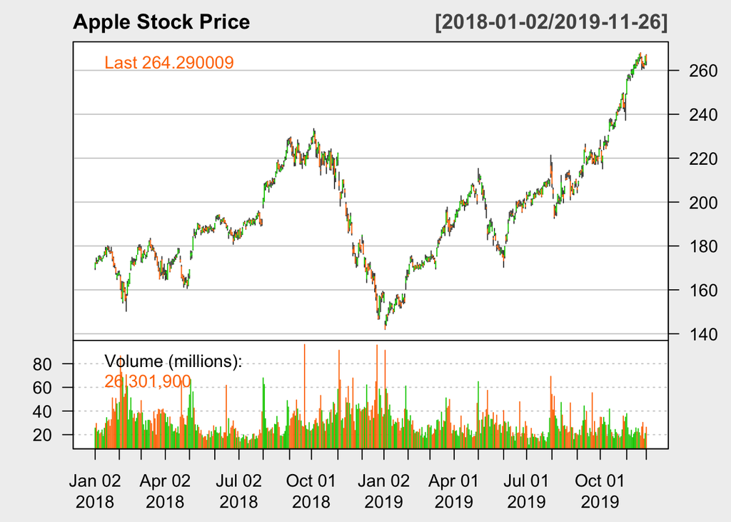

```r
chartSeries(AAPL, subset="2018/2019",
            theme="white", name="Apple Stock Price", major.ticks="months", minor.ticks=FALSE)
```

# Analysis of Yield Distribution Characteristic

*Why choose Log-Return?*

In the economics, we have Continuously Compounded Return whose distribution is similar as normal distribution. As the definition, Continuously compounded return is what happens when the interest earned on an investment is calculated and reinvested back into the account for an infinite number of periods.

1. One-period Simple Return:
   $$1 + R_t = \frac{P_t}{P_{t-1}} \quad or \quad P_t = P_{t-1}(1 + R_t)$$
2. Compound Return:
   $$(1 + \frac{r_t}{n})^n = (1 + \frac{r_t}{n})^\frac{n*r_t}{r_t}$$
3. When n → ∞, the function will be continous:
   $$\lim_{n \to +\infty} (1 + \frac{r_t}{n})^n = \lim_{n \to +\infty} (1 + \frac{r_t}{n})^\frac{n*r_t}{r_t} = e^{r_t}$$
4. Because of equation 1 and 2, we use Natural logarithm:
   $$r_t = ln(1 + R_t) = ln(\frac{P_t}{P_{t-1}})$$
5. Due to Logarithmic properties:
   $$r_t[k] = ln[(1+R_t)(1+R_{t-1})...(1+R_{t-k+1})] = r_t + r_{t-1} + ... + r_{t-k+1}$$

## Calculating the Log-Return

```r
logret.AAPL <- diff(log(AAPL$AAPL.Adjusted))*100
str(logret.AAPL)
```

```
## An 'xts' object on 2007-01-03/2019-11-26 containing:
##   Data: num [1:3249, 1] NA 2.195 -0.715 0.493 7.98 ...
##  - attr(*, "dimnames")=List of 2
##   ..$ : NULL
##   ..$ : chr "AAPL.Adjusted"
##   Indexed by objects of class: [Date] TZ: UTC
##   xts Attributes:
## List of 2
##  $ src    : chr "yahoo"
##  $ updated: POSIXct[1:1], format: "2019-11-27 01:12:18"
```

```r
summary(logret.AAPL)
```

```
##      Index            AAPL.Adjusted
##  Min.   :2007-01-03   Min.   :-19.74699
##  1st Qu.:2010-03-25   1st Qu.: -0.77669
##  Median :2013-06-17   Median :  0.10070
##  Mean   :2013-06-15   Mean   :  0.09956
##  3rd Qu.:2016-09-06   3rd Qu.:  1.10560
##  Max.   :2019-11-26   Max.   : 13.01942
##                       NA's   :1
```

```r
head(logret.AAPL) %>% kable() %>% kable_styling() %>% scroll_box(width="200px")
```

| AAPL.Adjusted |
| --- |
| NA |
| 2.1952752 |
| -0.7146552 |
| 0.4926396 |
| 7.9799664 |
| 4.6745721 |

## Graph of Log-Return

### Time Series Curve of Log-Return in 2007-2019

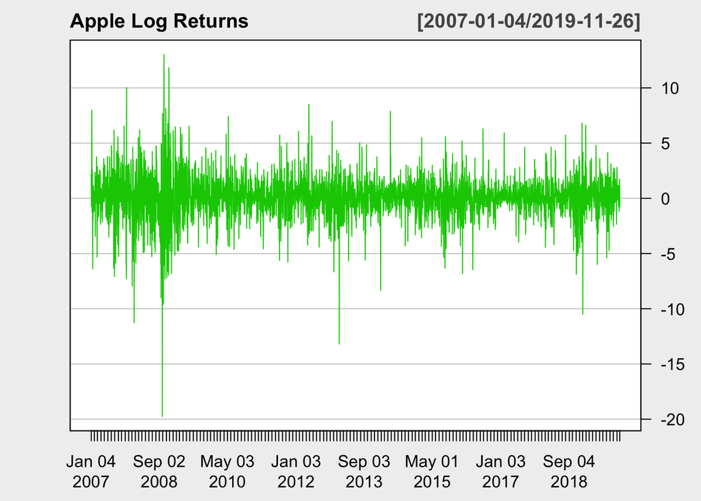

```r
chartSeries(logret.AAPL,
            type="l", TA=NULL,
            subset="2007/2019",
            name="Apple Log Returns",
            theme="white", major.ticks="months", minor.ticks=FALSE)
```

### Time Series Curve of Log-Return in 2018-2019

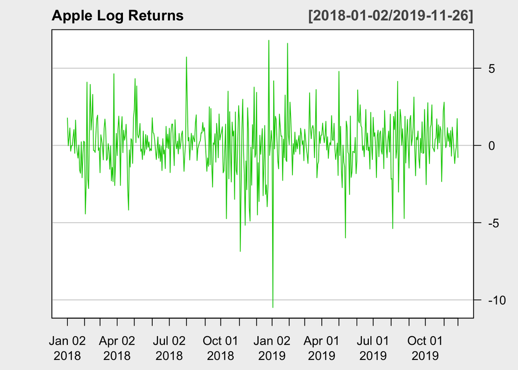

```r
chartSeries(logret.AAPL,
            type="l", TA=NULL,
            subset="2018/2019",
            name="Apple Log Returns",
            theme="white", major.ticks="months", minor.ticks=FALSE)
```

### Histogram of Log-Return

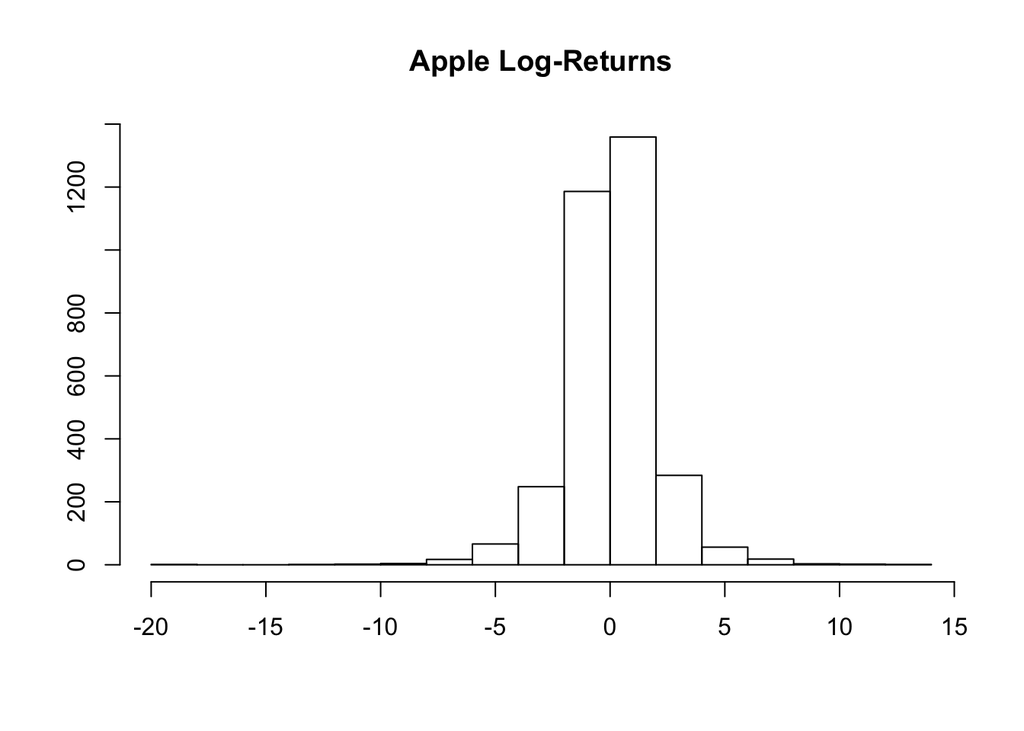

```r
x <- coredata(logret.AAPL)
hist(x, main="Apple Log-Returns", xlab="", ylab="")
```

### Q–Q Plot of Log-Return

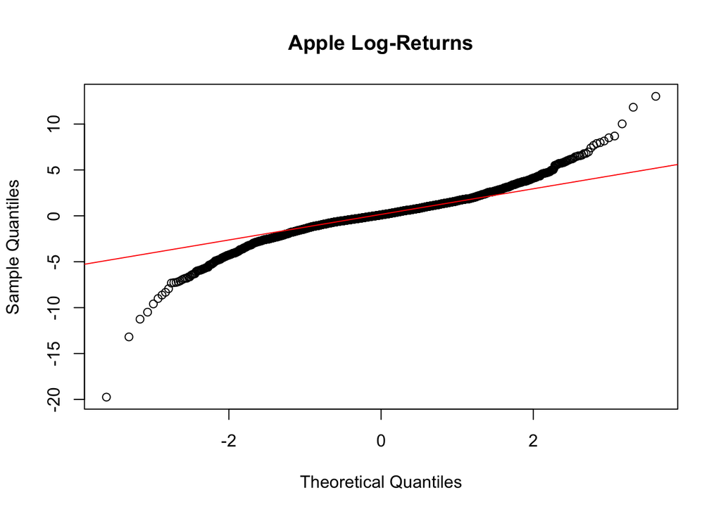

```r
x <- coredata(logret.AAPL)
qqnorm(x, main="Apple Log-Returns")
qqline(x, col="red")
```

From Time Series Curve, Histogram, Q-Q Plot, the stock log-return has Fat-tailed distribution.

PS: A fat-tailed distribution is a probability distribution that exhibits a large skewness or kurtosis, relative to that of either a normal distribution or an exponential distribution.

```r
x <- coredata(diff(log(AAPL["2018/2019"]$AAPL.Adjusted)))[-1]
fBasics::basicStats(x)
```

```
##                      x
## nobs        479.000000
## NAs           0.000000
## Minimum      -0.104924
## Maximum       0.068053
## 1. Quartile  -0.007116
## 3. Quartile   0.010182
## Mean          0.000956
## Median        0.001326
## Sum           0.457857
## SE Mean       0.000807
## LCL Mean     -0.000630
## UCL Mean      0.002541
## Variance      0.000312
## Stdev         0.017659
## Skewness     -0.564182
## Kurtosis      4.145202
```

In the result, Kurtosis > 3, which means it is “excess kurtosis”.

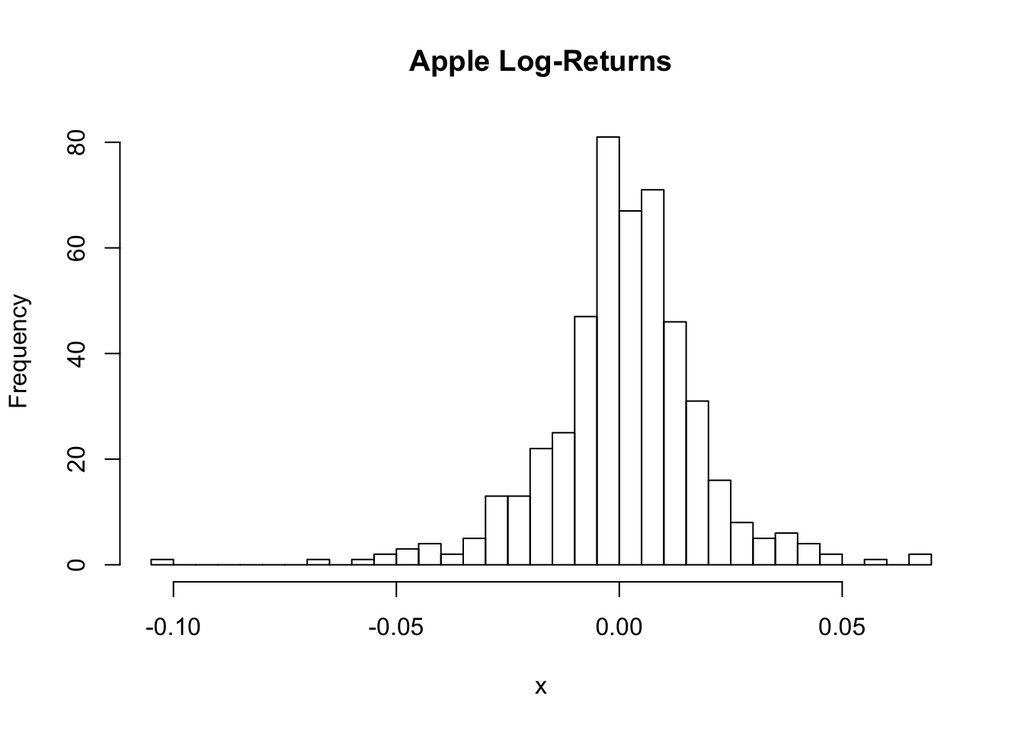

```r
hist(x, nclass=30, main="Apple Log-Returns")
```

## T test

```r
t.test(x)
```

```
##
##  One Sample t-test
##
## data:  x
## t = 1.1847, df = 478, p-value = 0.2367
## alternative hypothesis: true mean is not equal to 0
## 95 percent confidence interval:
##  -0.0006295447  0.0025412648
## sample estimates:
##    mean of x
## 0.0009558601
```

## Autocorrelation Function Graph and Partial Autocorrelation Graph

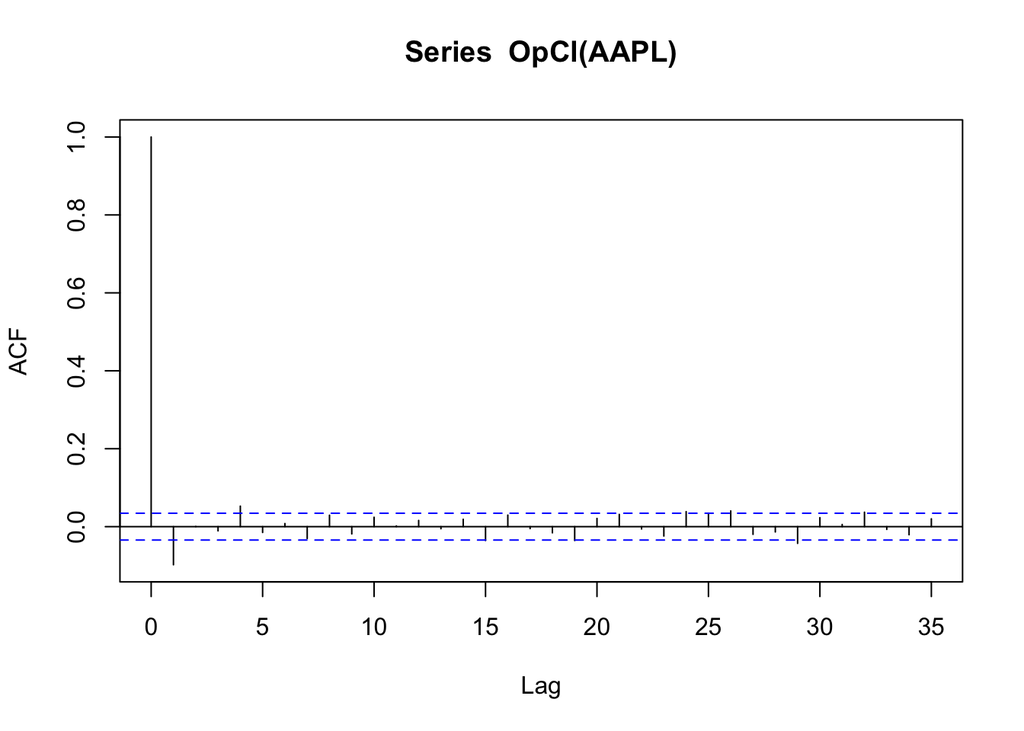

```r
acf(OpCl(AAPL))
```

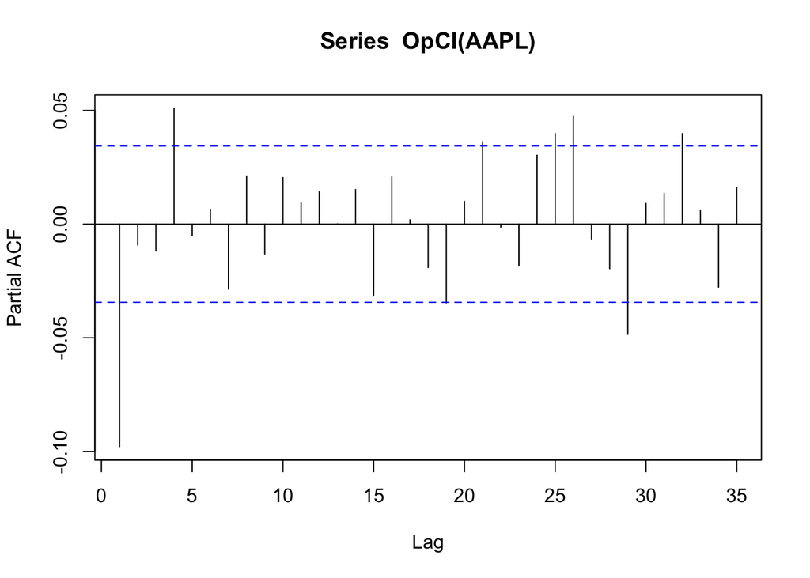

```r
pacf(OpCl(AAPL))
```

In these two graph, both autocorrelation coefficient and partial autocorrelation coefficient decay very quickly to 0.

```r
model_arima<-auto.arima(OpCl(AAPL))
model_arima
```

```
## Series: OpCl(AAPL)
## ARIMA(1,0,0) with zero mean
##
## Coefficients:
##           ar1
##       -0.0979
## s.e.   0.0175
##
## sigma^2 estimated as 0.0002598:  log likelihood=8801.32
## AIC=-17598.63   AICc=-17598.63   BIC=-17586.46
```

For the forecasts from ARIMA(1,0,0) above, we need use AR(1) for forecasts.

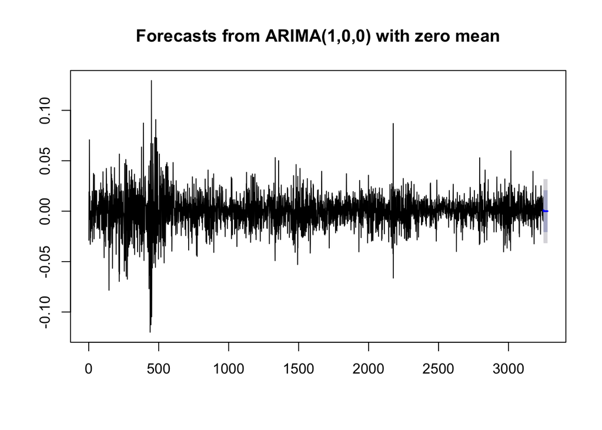

```r
pre_arima <- forecast(model_arima,h=30)
plot(pre_arima)
```

# Analysis in ts class

## Create the week of Log-Return in 2018-11-26 to 2019-11-22

```r
AAPL$logret <- diff(log(AAPL$AAPL.Adjusted))*100
AAPL$week <- week(format(index(AAPL)))
new_AAPL <- AAPL["2018-11-26/2019-11-22", c("logret", "week")]
new_AAPL <- as.data.frame(new_AAPL)
new_AAPL <- aggregate(logret ~ week, data = new_AAPL, sum)
new_AAPL <- rbind(new_AAPL[48:53,], new_AAPL[1:47,])
new_AAPL <- new_AAPL$logret
# Becasue 2018-12-31 and 2019-01-02 in the same week, we need to add them up.
new_AAPL[6] <- sum(new_AAPL[6], new_AAPL[7])
new_AAPL <- new_AAPL[-7]

summary(new_AAPL)
```

```
##     Min.  1st Qu.   Median     Mean  3rd Qu.     Max.
## -11.1759  -0.5637   1.3799   0.8332   2.6292  10.5487
```

```r
str(new_AAPL)
```

```
##  num [1:52] 3.59 -5.82 -1.8 -9.34 3.58 ...
```

```r
head(new_AAPL)
```

```
## [1]  3.585762 -5.816020 -1.802621 -9.336019  3.583918 -5.458999
```

```r
# Creating Time Series Object
logret.week <- ts(new_AAPL, frequency=52, start=c(2018, 11, 26))
str(logret.week)
```

```
##  Time-Series [1:52] from 2018 to 2019: 3.59 -5.82 -1.8 -9.34 3.58 ...
```

## Time Series Plot

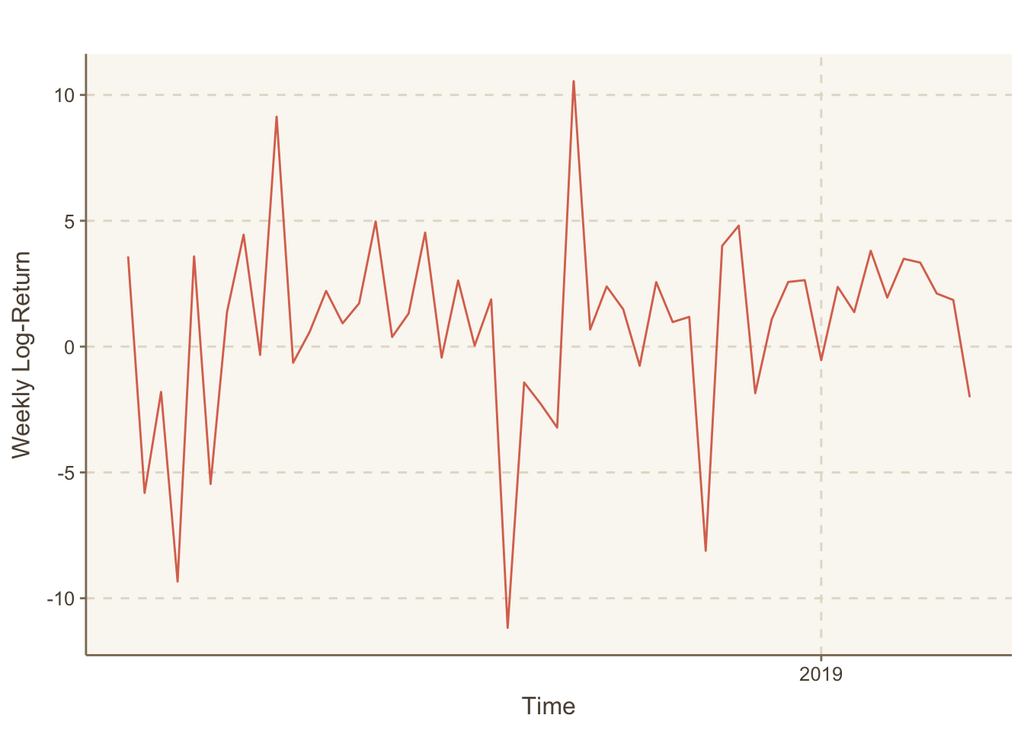

```r
autoplot(logret.week) + ylab("Weekly Log-Return")
```

## Autocorrelation Function Graph

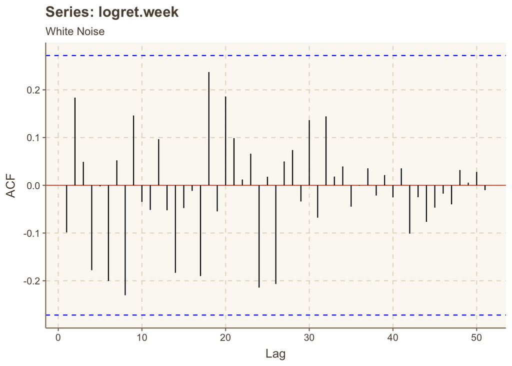

```r
ggAcf(logret.week) + ggtitle("Series: logret.week", subtitle = "White Noise")
```

## Forecast Next 30 Values for Weekly Log-Return

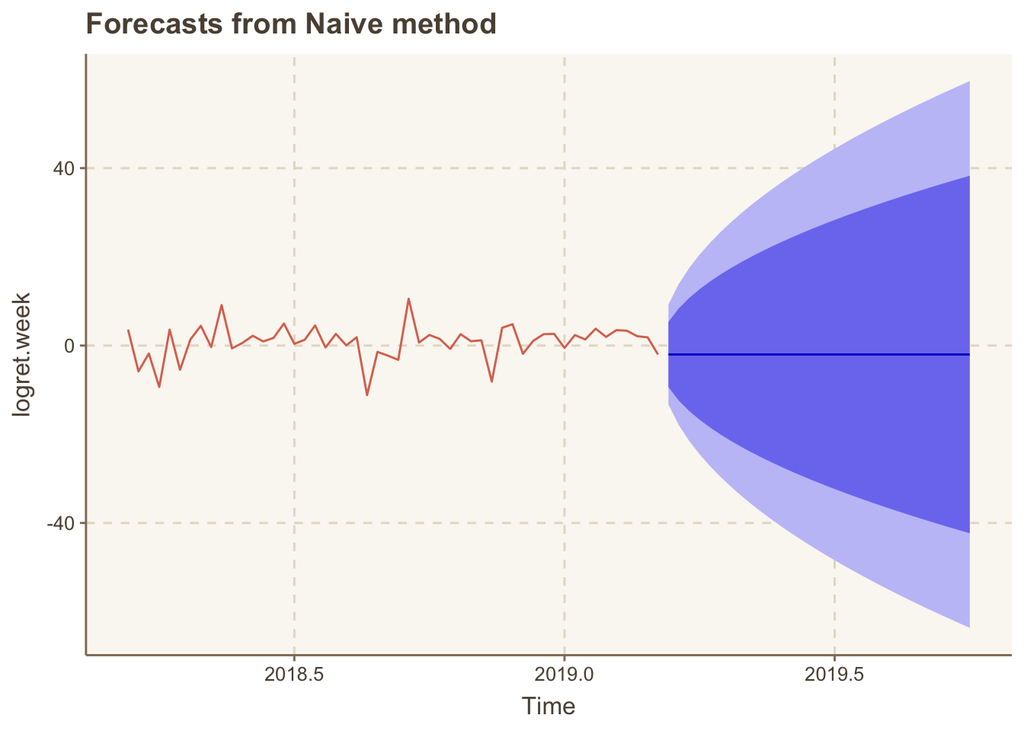

```r
fc_AAPL <- naive(logret.week, 30)
autoplot(fc_AAPL)
```

## Fitted Values and Residuals

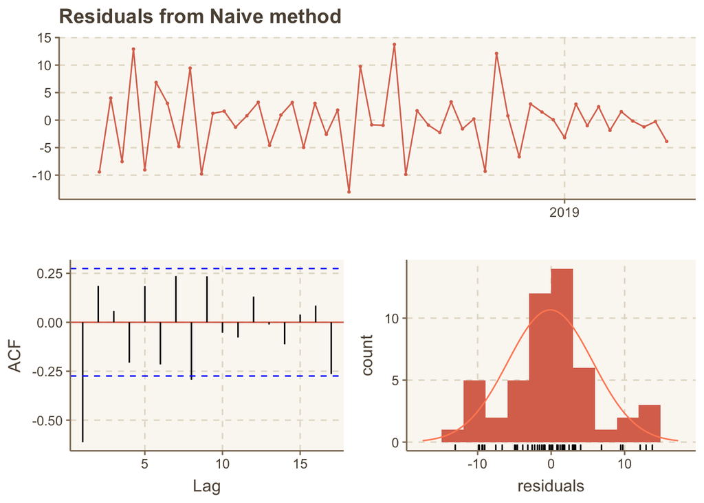

```
##
##  Ljung-Box test
##
## data:  Residuals from Naive method
## Q* = 42.151, df = 10, p-value = 7.049e-06
##
## Model df: 0.   Total lags used: 10
```

```r
checkresiduals(fc_AAPL)
```